# Lab 8

Note, this is a group project. You will need to work with your final project group on this lab. **Each member of your group should make at least one commit**. Once you have completed the assignment, provide a link to the repository in the text box for the lab on Canvas.

1. Create a shared github repo for this lab. Call it “w5-lab”

### Commit 1

1. Use {papaja} to create an APA document that renders to a PDF manuscript
- Give it a new title and running head
- Add all the authors
- Remove the author note
- Change the abstract to something else.
- Add some keywords
- Remove line numbers
- Remove the wordcount

### Commit 2

1. Add a data folder to the repo. Place *star.csv* into the repo.
2. Write code in the Rmd document to load all the libraries that will be used in the document, and setup global options. Make the code not show anywhere in the document, set figure width to 6.5 and figure height to 8.
3. Write the code to load the data.

### Commit 3

1. Create a bibliography with at least two references.
2. Include in-text examples of citations formatted as **Author (Year)** and **(Author, Year)**.
3. Render the document and make sure the reference section has a level 1 header of “References”, with all references displayed on their own page

### Commit 4

1. Write the code to create summary statistics. Output the following table and  
   briefly describe it in text.

| sex | frl | math_mean | math_sd | rdg_mean | rdg_sd |
| --- | --- | --- | --- | --- | --- |
| boy | no | 492.85 | 46.34 | 441.46 | 32.32 |
| boy | yes | 469.87 | 46.09 | 425.38 | 26.63 |
| girl | no | 501.21 | 45.96 | 448.54 | 34.52 |
| girl | yes | 477.51 | 46.30 | 430.80 | 27.42 |

### Commit 5

1. Create the following plot, using whatever theme you’d like, and briefly discuss it in text.

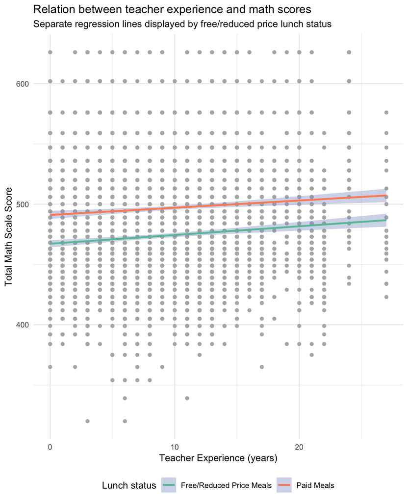